# review slides

### TIME AND PLACE

- **Time:** 7:00 PM - 8:00 PM
- **Place:** [LTD, LTG, 1103](https://pathadvisor.ust.hk/floor/Overall/at/normalized/1520,1972,3)
- **Closed book**, no external resources.

### Format:

- Five numbered sections
- The first four each will come directly from one of P1-7 or case 2.
- Each of these will have several questions (denoted by letters) that you should answer.
- The final section will be multiple choice questions about the concepts from the tax lectures.
- You can skip one section and should budget 15 minutes per section, though the tax concepts section will likely not require 15 minutes.

### Example Section 1: Dr. Morris's biography

I teach Advanced Managerial Accounting at the Hong Kong University of Science and Technology (HKUST). I research the relationships that form within and across the boundaries of the firm, how stakeholders use contracts to formalize these relationships, and how those contracts shape behavior.

Before taking my current position in Hong Kong, I taught at NYU - Shanghai where I was an Assistant Professor and Faculty Fellow.

- (a.) What does Dr. Morris research?
- (b.) Based on Dr. Morris's lectures, does he think that it is easy to write good contracts?
- (c.) Where was Dr. Morris's previous appointment?
- (d.) ... etc.

> Which topics will be examined and which are the focus of our revision?

The questions will come from problems 1-7 and case 2, as well as the key concepts from the tax lectures.

> And how’s the format of our mid-term?

The exam will be a combination of short essays, short answers and multiple choice.

> Do we use electronic devices for excel/python problems?

No. I will ask you how to set up analysis, but you will not need to do the calculations on the exam.

> Also, how would the questions look like? ( we cannot use Excel at that time!)
- You will only be responsible for describing set-up and interpretation.

> Will midterm format be MC or LQ questions?

The exam will be a mix of short answers, short essays (less than half of a page and can be answered with bulleted lists), and multiple choice. (I don't know what LQ are).

> will real and finance assets and economics of agency be covered in midterm?
- The information from the tax lectures will be only from the list of key concepts (see slide below)

> Will we be asked for definition of implicit tax sth similar like that?
- Yes, see the tax slide below for details.

> Do we need to remember the formulae?
- You will not be asked to produce formulae from memory, however you should understand the intuition behind them and how to manipulate them.

> In class you mentioned that you will ask questions on our intuition and understanding of key concepts.
- This is correct, but this includes being able to set up analyses and interpret results.

> However, noting that most of the canvas problems require Excel for computations,
- For problems that you solved with Excel or python I am interested in the set up and interpretation of results. So I will adapt the question to focus on those aspects.

> does it mean we have to recite some sort of functions (such as functions for marginal cost, shadow prices, etc.) as well?
- There is no need to memorize and recite formulas for marginal cost and shadow prices. This is because every cost function has it's own marginal cost, and—if constrained—its own shadow price.
- If given a cost function you should be able to determine the marginal cost, and if given a constrained maximization problem you should be able to articulate what the shadow price is. You will not be asked to derive or calculate the shadow price.

> Will the solutions of the problem sets be disclosed?
- Yes, the lectures and review sessions have been devoted to teaching you how to solve the problem sets.

> is it possible for you to provide the full answers for the assignments?
- Every numeric answer that I will ask you about is in the slides.
- Every conceptual question that I will ask you about has been covered in the slides/lectures.

> I saw your PowerPoint and it said that you would ask us to explain the steps instead of giving out the answer. So do I answer by telling you how to do the question by explaining what would I do with excel?

This is the sort of thing that I will ask you to do, but I won't ask for you to do the actual calculations. I'm more interested in whether you understand which information you need to use and how to use it.

### Key tax concepts:

1. Assets, investments, and projects all have different pre-tax returns ($r$).
2. Tax rates $t$ vary across individuals, jurisdictions, organizations, and assets.
3. pre-tax returns $r$ correspond to post tax returns $r(1-t)$
4. When preferential tax treatment increases demand for a tax favored asset it's price increases and/or the return to holding it decreases. This price change is an *implicit* tax.
5. When tax payers use organizational forms like pensions and insurance policies to avoid taxes it is called *organizational form arbitrage*.
6. When high-tax tax payers issue taxable debt to finance the purchase of tax free debt (e.g. municipal bonds in the US) issued by low-tax tax payers (e.g. US non-profit universities) it is called *clientele arbitrage*.
7. The depreciation *tax shield* is the present value of the reduction in tax payments afforded by the depreciation deduction.
8. The value of the tax shield $TS$ is a function of the investment $x$, the cash flow it generates $k$, the risk-free rate of return $r$, the tax rate $t$, and the depreciation rate $d$. $$TS=f(x,k,t,d,r)$$
9. $TS$ is increasing in both $d$ and $t$.

### The SPDA formula will NOT be on the exam. I will not ask you about it.

[figure not shown]

1. What is the economic significance of the area to the left of the line from X to A?
2. What is the economic significance of the area between X->A and Y->B?
3. What is the economic significance of the area to the right of Y->B?

**Key insight:** at the extremes linear approximations are not useful, and $MC\neq IC$

> could you give us some sample answer about "What is the economic significance of nonlinearities in the cost functions"? since i cannot find that in the slide.
- "economic significance" means "real-world significance"
- Nonlinearities in cost functions mean that marginal cost changes with the quantity produced.

> In problem set 5, you mentioned that if two products are inseparable, then the marginal cost will be 36, not 30, could you explain again why it is 36? (I just missed that part, sorry about that)
- If we consider production choice to be separate then the cost of x is simply the input price of x which is 30.
- If the choice of x changes our choice of y then the cost of x includes its impact on profit through it's impact on y.
- If the choices are linked then we need to consider the direct cost of x **and** the opportunity cost (profit foregone) of its effect on y.

> Could you explain what is implicit rate and why ignoring implicit taxes leads to overestimation of the risk premium applicable to corporate debt?
- Simply put, risk premiums and implicit taxes both increase prices (yields on loans/interest rates).
- Thus, tax favored assets will tend to be less risky than taxed assets with similar prices.
- This particular issue will not be on the exam, I will just ask for the definition of the implicit tax.

> Lecture 7 – Capital budgeting example

> Option 1 - Why is space-related cost -6500*80 not -6500*50
- The current space costs 50/sqft. We pay this in either case, so it does not factor into our decision.
- **If we keep running the department we will need to rent 6500 more sqft at 80/sqft**. If we close the department we will not need to rent this space.

> Lecture 8 Excel example– Question 3 sheet
- This will not be on the exam! The questions will put decreasing weight/difficulty on later topics, please refer to the key tax concepts slide.

> why is Tax deduction benefit on interest that could have been avoided: Interest payments avoided *tax rate as opposed to cash flow of SPDA at age 44.5* (1+11%)^15

> I have a question regarding the following sentences in chapter 8 about tax shields. "When the pre-tax yields on munis and taxable debt equilibrate, say at 8%, then it become possible for all entities that face a positive explicit rate of tax to generate sufficient deductions to eliminate all tax payments."

> Is it intuition here to issue taxable bonds, and use the money from the bond to buy muni bonds, that is lending money to those tax-exempt organizations, so the interest income earned from the money lent will be tax-free?

This is correct, but initially—if municipal bonds are scarce--two things prevent taxes from being eliminated.

- First, if municipal bonds are scarce, there will be insufficient bonds for all taxpayers to enact the strategy you described.
- Second, again if municipal bonds are scarce, demand for them will create implicit taxes (lower yields) which will make it less/unattractive for some tax payers to follow the strategy. This is most clear in the case where the implicit tax is above the taxpayer's marginal tax rate. Taxpayers can only avoid tax up to the implicit tax rate.

Notice what happens if there is an implicit tax. Yields are lower, which means that those who can issue municipal bonds have access to low-cost debt which they can in turn lend to higher tax organizations and individuals and make a risk-free profit.

This is an arbitrage opportunity. This will attract more and more municipal lenders who all supply more and more debt until municipal bonds are no longer scarce. Since both things that prevent taxes from being eliminated depend on scarcity now:

- There is no implicit tax so tax payers can use the strategy you summarized to eliminate all of their taxed.
- There is enough municipal debt for everyone who wants to do this to do it.

In practice the amount of debt needed to do this is orders of magnitude higher than the amount of municipal debt that is actually in the market.

> I also want to ask if I issue bonds, then should I pay the tax or the lender who lends the money to me should pay the tax on interest?

This is a great question! When you issue a bond you get an asset (the money you borrowed) and a liability (your responsibility to pay that money back). This means that the borrower (you) gets no income from issuing a bond, and thus nothing to tax. The borrower also makes interest payments (shows up as interest expense on your books) to the lender (shows up as interest income on their books) these interest payments are taxable income for the lender.

> "Cost in a Multiproduct Firm Part 2 for tomorrow’s review session?"
- In general this student was interested in how to approach the open ended questions from the homework.
- The homework was intended to get you thinking about these topics.
- I will ask direct questions rather that just "interpret your optimal production plan".
- For example, I might ask something like "We always pick k=200 under these assumptions, what does this suggest?"

> The main takeaways of I got from lecture 4 (P4) are : there are synergy for the company to produce 2 products if there are idle capacities,
- I want to be careful to point out that "idle capacity" is just one real-world example of how this might play out.
- The more general ideal here is that when the capital is shared you can make both products with it.
- So if you purchase 200 units of K for the purpose of producing q2 you can use that 200 K to produce q1 as well. *This is what it means to share capital.*

> and we will decide the outputs based on the binding constraint K.
- In general, the constraint only matters when it binds, or when it is the constraint that prevents you from profitably producing more.

You manage a two-product firm. The production technology requires a mixture of capital and labor to produce each product. Capital is shared, while labor is specific to each of the two products. For the first product, capital ($K \geq 0$) and labor ($L_1 \geq 0$) must satisfy the following, in order to produce $q_1$ units: $q_{1} \leq \sqrt{KL_{1}}$. Likewise, producing $q_2$ units of the second product requires capital ($K$) and labor (now $L_2 \geq 0$) such that: $q_2 \leq\sqrt{KL_2}$. In addition, total capital is limited to a maximum of 200 units. (So $K \leq 200$.) Naturally, $K$, $L_1$, $L_2$ are all required to be non-negative. Capital costs 100 per unit, labor for the first product costs 140 per unit and labor for the second product costs 175 per unit. The first product sells for 275 per unit, and the second sells for 300 per unit.

1. Initially suppose only the first product is present. Determine and interpret your optimal production plan.
2. Next suppose only the second product is present. Determine and interpret your optimal production plan.
3. Now assume both products are present. Determine and interpret your optimal production plan.
4. Repeat the three parts above assuming the first product sells for 200 per unit.

### Here I am likely to ask you about

1. how to set up an optimization problem.
   - set up the objective function
   - identify the choice variables
   - identify the constraints
2. what it means to have a constraint bind.
3. what does it mean if the optimal production plan is 0
4. why does the optimal production plan change based on the production of the other product.
5. $q_{1} \leq \sqrt{KL_{1}}$ this means that the amount of $q$ you get from each additional unit of labor increases with K, but at a decreasing rate (this is because of the square root). So there are two factors driving the changes in marginal cost:
6. The effect of the marginal unit on the consumption of capital. You can see this in the tables at the end of Lecture 4
7. The scale of the firm at the margin.

### Optimal production plan for $q_1$ alone:

Let's refer to the prices as "P", and the labor and capital costs as "C" $$ \Pi(P,C) \equiv 275 \times q_1 - 140 \times L_1 - 100 \times K $$ $$ q_1 \leq \sqrt{L_1 \times K} $$ $$ K \leq \bar{K} = 200 $$

This makes it seem like we have more choices than we actually have. The constraint (production function) makes it so that we can only choose two of K, q1, and l1.

$$ \Pi(P,C) \equiv 275 \times q_1 - 140 \times \frac{q_1^2}{K} - 100 \times K $$$$ K \leq \bar{K} = 200 $$

### So what do we do with this?

$$ \Pi(P,C) \equiv 275 \times q_1 - 140 \times \frac{q_1^2}{K} - 100 \times K $$$$ K \leq \bar{K} = 200 $$

How do we choose the optimal production plan?

There are a number of approaches, I'm going to show you a very general python solver. This will be useful for those of you that are using python, I want the rest of you to focus on the steps we are taking so you can apply them to whatever solver you like. (Excel example will be posted soon)

## Since this is not a linear problem let's use [GEKKO](https://gekko.readthedocs.io/en/latest/)

```python
# set up the solver
from gekko import GEKKO
m = GEKKO(remote=False)
```

### Step 1: Choice Variables and their constraints

```python
# Initialize the decision variables
q1 = m.Var(
    name="q1",
    lb=0 # the lower bound
)
q1.value=1 # most solvers run faster when you give a starting point

k =  m.Var(
    name="k",
    lb=0, # lower bound
    ub=200 # upper bound
)
k.value=200 # this is our first guess to speed up the solution
```

### Step 2: Write down the objective function (what we want to maximize), any remaining constraints, and solve.

$$ \Pi(P,C) \equiv 275 \times q_1 - 140 \times \frac{q_1^2}{K} - 100 \times K $$

*What happened to $ K \leq \bar{K} = 200 $?*

```python
m.Maximize(
    275*q1 - 140*((q1**2)/k) - 100*k
)
m.solve(disp=False) # silencing the out put because it is diagnostic
```

The output from the model is just the choice variables so we need to calculate profit and labor:

```python
profit = (275*q1.value[0] - 140*((q1.value[0]**2)/k.value[0]) - 100*k.value[0])
l1 = q1.value[0]**2/k.value[0]
```

### This gives us the following solutions

(note that I'm rounding here)

```python
print('q1     ', int(q1.value[0]))
print('l1     ',int(l1))
print('K      ', int(k.value[0]))
print('profit ', int(profit))
```

```
q1      196
l1      192
K       200
profit  7008
```

### Optimal production plan for $q_2$ alone:

We make a similar substitution here:

```python
# same set up repeated to clean out 'm'
m = GEKKO(remote=False)
q2 = m.Var(name="q2", lb=0)
q2.value=1
k =  m.Var(name="k", lb=0, ub=200)
k.value=200
```

### Write down the objective function again and solve:

```python
m.Maximize(
    300*q2 - 175*((q2**2)/k) - 100*k
)
m.solve(disp=False)
profit = (300*q2.value[0] - 175*((q2.value[0]**2)/k.value[0]) - 100*k.value[0])
l2 = q2.value[0]**2/k.value[0]
```

### This gives us the following solutions

(note that I'm rounding here)

```python
print('q2     ', int(q2.value[0]))
print('l2     ',int(l2))
print('K      ', int(k.value[0]))
print('profit ', int(profit))
```

```
q2      171
l2      146
K       200
profit  5714
```

### Optimal production plan for both:

```python
# reset gekko
m = GEKKO(remote=False)
# Initialize the decision variables
q1 = m.Var(name="q1", lb=0)
q1.value=1
q2 = m.Var(name="q2", lb=0)
q2.value=1
k =  m.Var(name="k", lb=0, ub=200)
k.value=200
```

```python
# write the objective function  and solve
m.Maximize(
    275*q1 - 140*((q1**2)/k)
    + 300*q2 - 175*((q2**2)/k)
    - 100*k
)
m.solve(disp=False)
```

```python
# quick calcs to clean things up
profit = (
    275*q1.value[0] - 140*((q1.value[0]**2)/k.value[0])
    + 300*q2.value[0] - 175*((q2.value[0]**2)/k.value[0])
    - 100*k.value[0]
)
l1 = q1.value[0]**2/k.value[0]
l2 = q2.value[0]**2/k.value[0]
```

### This gives us the following solutions

(note that I'm rounding here)

```python
print('q1     ', int(q1.value[0]))
print('l1     ',int(l1))
print('q2     ', int(q2.value[0]))
print('l2     ',int(l2))
print('K      ', int(k.value[0]))
print('profit ', int(profit))
```

```
q1      196
l1      192
q2      171
l2      146
K       200
profit  32723
```

### We always pick k=200. What does this mean?

- This means that the capital constraint is preventing us from making the next unit.
- When a constraint does this we often call it a binding constraint.

### The q1,L1 and q2,L2 pairs that we pick are the same when we consider the products separately and together. What does this mean?

- It means that the profit function is **separable** when the capital constraint is binding.

### Repeat all three steps with $P_1=200$

```python
m = GEKKO(remote=False)
q1 = m.Var(name="q1", lb=0)
q1.value=1
q2 = m.Var(name="q2", lb=0)
q2.value=1
k =  m.Var(name="k", lb=0, ub=200)
k.value=200
m.Maximize(
    200*q1 - 140*((q1**2)/k) - 100*k
)
m.solve(disp=False) # silencing the out put because it is diagnostic
profit = (
    200*q1.value[0]
    - 140*((q1.value[0]**2)/k.value[0])
    - 100*k.value[0]
)
l1 = q1.value[0]**2/k.value[0]
```

### $Q_1$ when $P_1=200$

```python
print('q1     ', int(q1.value[0]))
print('l1     ',int(l1))
print('K      ', int(k.value[0]))
print('profit ', int(profit))
```

```
q1      0
l1      0
K       0
profit  0
```

### The optimal amount of Q1 to produce is 0.

What does this mean?

What does this mean? This means that a firm that only produces Q1 should not produce it at this price, given this cost structure. What does this mean for a firm that produces Q2? What should they do? enter the market for Q1 or not?

### Lets look at the profit functions for the two single product firms with k=200

```python
# set up
def Pi1(q1):
    return 200*q1 - 140*((q1**2)/200)
def Pi2(q2):
    return 300*q2 - 175*((q2**2)/200)
q1=np.linspace(0,300,300)
q2=np.linspace(0,300,300)

Pq1=Pi1(q1)- 100*200
Pq2=Pi2(q2)- 100*200
```

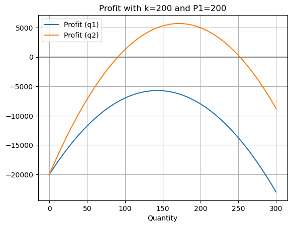

```python
plt.plot(q1,Pq1,label='Profit (q1)')
plt.plot(q1,Pq2,label='Profit (q2)')
plt.xlabel('Quantity')
plt.legend()
plt.grid()
plt.axhline(0, color='grey')
plt.title('Profit with k=200 and P1=200')
plt.show()
```

### $Q_1$ and $Q_2$ when $P_1=200$

Now we are back to the multiproduct firm

```python
# Let's look at the two together
# reset gekko
m = GEKKO(remote=False)
# Initialize the decision variablesc
q1 = m.Var(name="q1", lb=0)
q1.value=1
q2 = m.Var(name="q2", lb=0)
q2.value=1
k =  m.Var(name="k", lb=0, ub=200) # this is the constraint
k.value=200 # this is our first guess to speed up the solution
m.Maximize(
200*q1 - 140*((q1**2)/k)
+ 300*q2 - 175*((q2**2)/k)
- 100*k
)
m.solve(disp=False)
profit = (
    200*q1.value[0] - 140*((q1.value[0]**2)/k.value[0])
    + 300*q2.value[0] - 175*((q2.value[0]**2)/k.value[0])
    - 100*k.value[0]
)
l1 = q1.value[0]**2/k.value[0]
l2 = q2.value[0]**2/k.value[0]
```

```python
print('q1     ', int(q1.value[0]))
print('l1     ',int(l1))
print('q2     ', int(q2.value[0]))
print('l2     ',int(l2))
print('K      ', int(k.value[0]))
print('profit ', int(profit))
```

```
q1      142
l1      102
q2      171
l2      146
K       200
profit  20000
```

### Lets plot this and see what it's telling us.

```python
# Create data for the plot
def bigPi(q1,q2,k=200):
    return 200*q1 - 140*((q1**2)/k)+ 300*q2 - 175*((q2**2)/k) - 100*k
q1=np.linspace(0,300,300)
q2=np.linspace(0,300,300)
Q1, Q2 = np.meshgrid(q1, q2)
Pi12 = bigPi(Q1,Q2)
```

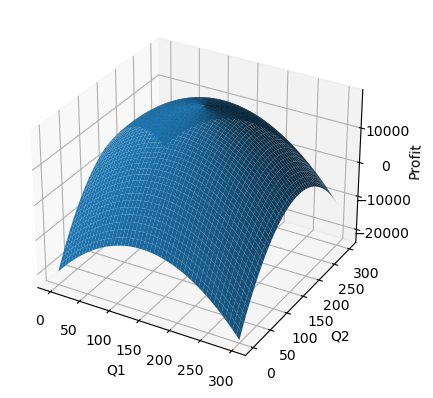

```python
# Create the figure and add a 3D axis
fig = plt.figure()
ax = fig.add_subplot(111, projection='3d')
# Plot the data
ax.plot_surface(Q1, Q2, Pi12)
# Set axis labels and show the plot
ax.set_xlabel('Q1')
ax.set_ylabel('Q2')
ax.set_zlabel('Profit')
plt.show()
```

### Let's zoom to the zero lower bound

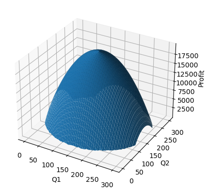

```python
Profit =  np.where(Pi12>0,Pi12,np.nan)
fig = plt.figure()
ax = fig.add_subplot(111, projection='3d')
ax.plot_surface(Q1, Q2, Profit)
ax.set_xlabel('Q1')
ax.set_ylabel('Q2')
ax.set_zlabel('Profit')
plt.show()
```

### What interesting insights or questions jump out from these facts?

- The functions are no longer separable
- The low contribution margin product, while unprofitable on it's own is may be profitable when it can share capital with a high contribution margin product.

## Why is this? What is going on?

- This is what it means to share capital.

## What are scenarios where this would play out in the real world?

- Adding a second product that does not compete with the first but that can be made using the same machines?
- A manufacturing firm takes on additional work with idle capacity.
- A retail firm adding a product line.